# Math 300 NTI Lesson 11

Simple Linear Regression - Continuous Predictor

Professor Bradley Warner

June, 2022

## Objectives

1. Use the `skimr` package to summarize multiple numerical variables in a data frame.
2. Build a scatterplot to describe the relationship between two continuous, numerical variables; use `geom_smooth()` to visualize the best fit line.
3. Fit a linear regression model between two variables using the `lm()` function and interpret the output. This includes the interpretation of slope and the use of *association* and not *causation*.
4. Generate a table of observations, fitted values, and residuals from a linear regression object.

## Reading

[Chapter 5 - 5.1](https://moderndive.com/5-regression.html)

## Lesson

*Remember that you will be running this more like a lab than a lecture. You want them using `R` and answering questions. Have them open the notes rmd and work through it together.*

Work through the learning checks LC5.1 - LC5.3.

- Regression can be used for explanatory and predictive purposes. It falls on that line between traditional statistics/econometrics and machine learning. In this course we focus on its more traditional use to interpret the relationship between predictors and a response. Math 378 is our machine learning course and expands on linear regression in this framework.
- Note the many different terms for `x` and `y` in regression. These names come from different fields. For example, `y` is called the response, dependent variable, outcome, and output. Meanwhile, `x` is called input, predictor, independent variable, and explanatory variable. Also point out that in linear regression, `y` is numerical while `x` can be numerical or categorical.
- We are using new packages. The `tidyverse` package is a wrapper and actually loads `readr`, `dplyr`, `ggplot2`, and `tidyr`.
- In the reading, the authors setup the problem with instructor teaching score as the response and beauty score as the explanatory variable. What is the research question?
- The reading introduces tilde `~` as a formula. You might want to talk about this as we use it in LC 5.1.
- The interpretation of the slope has the key phrase **average**. For a one unit change in `x`, the average value of `y` changes by the value of the slope.

### Setup

```r
library(tidyverse)
library(moderndive)
library(skimr)
library(gapminder)
```

*Create the data needed for the exercises.*

```r
evals_ch5 <- evals %>%
  select(ID, score, bty_avg, age)
```

Let’s look at 5 random rows of data.

```r
set.seed(1234)
evals_ch5 %>%
  sample_n(size = 5)
```

```
## # A tibble: 5 x 4
##      ID score bty_avg   age
##   <int> <dbl>   <dbl> <int>
## 1   284   4      1.67    34
## 2   336   3.1    1.67    60
## 3   406   5      2.83    57
## 4   101   4.4    4.33    48
## 5   111   3.5    4.33    57
```

### LC 5.1 (Objective 1)

**(LC5.1)** Refer to the example in section 5.1.1. Conduct a new exploratory data analysis with the same outcome variable $y$ being `score` but with `age` as the new explanatory variable $x$. Remember, this involves three things:

- Looking at the raw data values.
- Computing summary statistics.
- Creating data visualizations.

What can you say about the relationship between age and teaching scores based on this exploration?

**Solution**:

- Looking at the raw data values:

```r
glimpse(evals_ch5)
```

```
## Rows: 463
## Columns: 4
## $ ID      <int> 1, 2, 3, 4, 5, 6, 7, 8, 9, 10, 11, 12, 13, 14, 15, 16, 17, 18,~
## $ score   <dbl> 4.7, 4.1, 3.9, 4.8, 4.6, 4.3, 2.8, 4.1, 3.4, 4.5, 3.8, 4.5, 4.~
## $ bty_avg <dbl> 5.000, 5.000, 5.000, 5.000, 3.000, 3.000, 3.000, 3.333, 3.333,~
## $ age     <int> 36, 36, 36, 36, 59, 59, 59, 51, 51, 40, 40, 40, 40, 40, 40, 40~
```

- Computing summary statistics:

```r
my_skim<-skim_with(numeric = sfl(hist = NULL))
```

```r
evals_ch5 %>%
  select(score, age) %>%
  my_skim() %>%
  print()
```

```
## -- Data Summary ------------------------
##                            Values
## Name                       Piped data
## Number of rows             463
## Number of columns          2
## _______________________
## Column type frequency:
##   numeric                  2
## ________________________
## Group variables            None
##
## -- Variable type: numeric ------------------------------------------------------
##   skim_variable n_missing complete_rate  mean    sd   p0  p25  p50  p75 p100
## 1 score                 0             1  4.17 0.544  2.3  3.8  4.3  4.6    5
## 2 age                   0             1 48.4  9.80  29   42   48   57     73
```

```
## $numeric
##
## -- Variable type: numeric ------------------------------------------------------
##   skim_variable n_missing complete_rate  mean    sd   p0  p25  p50  p75 p100
## 1 score                 0             1  4.17 0.544  2.3  3.8  4.3  4.6    5
## 2 age                   0             1 48.4  9.80  29   42   48   57     73
```

(Note that for formatting purposes, the inline histogram that is usually printed with skim() has been removed.)

- Bivariate summary:

```r
evals_ch5 %>%
  get_correlation(formula = score ~ age)
```

```
## # A tibble: 1 x 1
##      cor
##    <dbl>
## 1 -0.107
```

- Creating data visualizations:

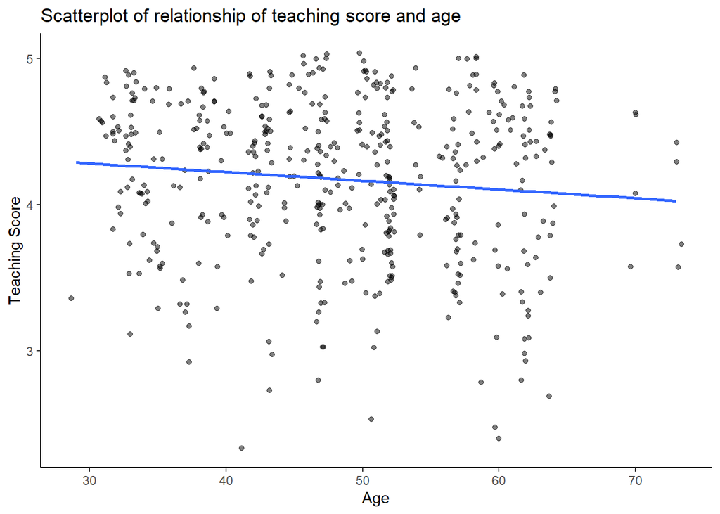

```r
ggplot(evals_ch5, aes(x = age, y = score)) +
  geom_jitter(alpha=0.5) +
  labs(
    x = "Age", y = "Teaching Score",
    title = "Scatterplot of relationship of teaching score and age") +
  geom_smooth(method = "lm", se = FALSE) +
  theme_classic()
```

Based on the scatterplot, there does not appear to be a relationship between age and teaching score. If anything, there might be a slight negative linear trend. That is, as age increases, the **average** teaching score decreases slightly. Even thought the correlation coefficient is negative, it is small in absolute value and thus there may be no relationship between the variables.

### LC 5.2 (Objective 2)

**(LC5.2)** Fit a new simple linear regression using `lm(score ~ age, data = evals_ch5)` where `age` is the new explanatory variable `x`. Get information about the “best-fitting” line from the regression table by applying the `get_regression_table()` function. How do the regression results match up with the results from your earlier exploratory data analysis?

**Solution**:

```r
# Fit regression model:
score_age_model <- lm(score ~ age, data = evals_ch5)
```

```r
# Get regression table:
get_regression_table(score_age_model)
```

```
## # A tibble: 2 x 7
##   term      estimate std_error statistic p_value lower_ci upper_ci
##   <chr>        <dbl>     <dbl>     <dbl>   <dbl>    <dbl>    <dbl>
## 1 intercept    4.46      0.127     35.2    0        4.21     4.71
## 2 age         -0.006     0.003     -2.31   0.021   -0.011   -0.001
```

$$\begin{aligned}
\widehat{y} &= b_0 + b_1 \cdot x\\
\widehat{\text{score}} &= b_0 + b_{\text{age}} \cdot\text{age}\\
&= 4.462 - 0.006\cdot\text{age}
\end{aligned}$$

For every increase of 1 year in `age`, there is an *associated* decrease of 0.006 units of the **average** teaching `score`. It matches with the results from our earlier exploratory data analysis.

### LC 5.3 (Objective 3)

**(LC5.3)** Generate a data frame of the residuals of the model where you used `age` as the explanatory $x$ variable.

**Solution**:

```r
score_age_regression_points <- get_regression_points(score_age_model)
```

```r
head(score_age_regression_points)
```

```
## # A tibble: 6 x 5
##      ID score   age score_hat residual
##   <int> <dbl> <int>     <dbl>    <dbl>
## 1     1   4.7    36      4.25    0.452
## 2     2   4.1    36      4.25   -0.148
## 3     3   3.9    36      4.25   -0.348
## 4     4   4.8    36      4.25    0.552
## 5     5   4.6    59      4.11    0.488
## 6     6   4.3    59      4.11    0.188
```

## Documenting software

- File creation date: 2022-06-21
- R version 4.1.3 (2022-03-10)
- `tidyverse` package version: 1.3.1
- `skimr` package version: 2.1.4
- `gapminder` package version: 0.3.0
- `moderndive` package version: 0.5.4